# Statistical Inference Project

Summers Weng

Tuesday, October 21, 2014

## Introduction to Project

The exponential distribution can be simulated in R with rexp(n, lambda) where lambda is the rate parameter. The mean of exponential distribution is 1/lambda and the standard deviation is also also 1/lambda. Set lambda = 0.2 for all of the simulations. In this simulation, you will investigate the distribution of averages of 40 exponential(0.2)s. Note that you will need to do a thousand or so simulated averages of 40 exponentials.

## Simulation

We are given rate parameter lambda eauals to 0.2 for an exponential distribution. Therefore, we know that mu and standard deviation must both be 5 for mu and standard deviation of exponential distribution are both the inverse of lambda. Next, we conduct 1000 times of randomly sample of 40 with lambda=0.2. The statistics of sampling distribution is provided below.

```r
## set seed
set.seed(12)
## build the simulations of 1000 times
simulation=NULL;simulation1000=NULL
for(i in 1:1000){
    simulation=rexp(40,0.2)
    simulation1000[i]=cbind(mean(simulation))
}
## tidy up the data and compute the statistics of sampling distributions.
mean(simulation1000)
```

```
## [1] 5.010015
```

```r
sd(simulation1000)
```

```
## [1] 0.7740594
```

From 1000 times of simulation, we got grand mean of 5.01 and standard error of 0.774. The distribution of this simulation centers around 5.01 with a standard error of 0.774. Our mu, which is 5, is almost equal to this grand mean(5.01). As we also know, the standard deviation for this exponential distriution is 5, too. According to Central Limit Thorem, standard error would be the standard deviation divided by square root of sample size as we show below, which is also very close to our simulation result(0.774).

```r
SE=5/sqrt(40)
print(SE)
```

```
## [1] 0.7905694
```

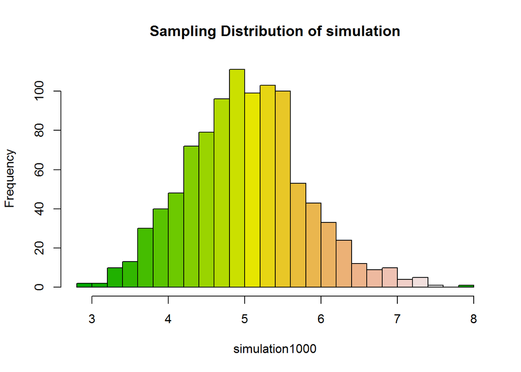

```r
hist(simulation1000,breaks=24,col=terrain.colors(24),main="Sampling Distribution of simulation")
```

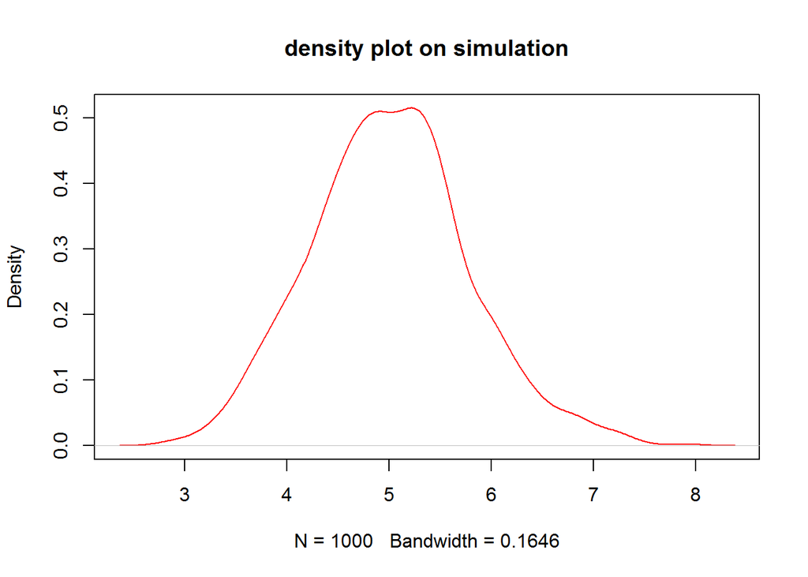

```r
plot(density(simulation1000),col="red",main="density plot on simulation")
```

```r
intervals=5.01+c(-1,1)*qnorm(0.975)*sd(simulation1000)
intervals
```

```
## [1] 3.492871 6.527129
```

The 95% confidence interval is 3.4928714, 6.5271286.